# Dissolved Oxygen Pipeline

## Introduction

**Why barometric data matters for DO:** Dissolved oxygen saturation depends on atmospheric pressure. A DO reading of 8 mg/L at sea level means something different than 8 mg/L at high elevation. By attaching barometric pressure, we can convert the raw mg/L reading into percent saturation (%sat) — a measure that accounts for altitude and weather conditions.

**Why drift correction matters:** DO sensors gradually lose accuracy over time as the sensing element degrades (“fouling”). Field reference measurements taken during site visits tell us how far the sensor has drifted. The drift correction adjusts the logged data so it matches the field references.

This vignette assumes you have already installed `waterlogged`:

```r
install.packages("pak")
pak::pkg_install("dfo-pacific-science/waterlogged")
```

## Setup

```r
library(waterlogged)
```

Define paths to the test data shipped with the package.

```r
metadata_file  <- system.file("extdata/metadata/metadata.csv", package = "waterlogged")
baro_folder    <- system.file("extdata/barometric_pressure/clean", package = "waterlogged")
do_folder      <- system.file("extdata/dissolved_oxygen/DO/raw", package = "waterlogged")
```

## Bind Raw Dissolved Oxygen Logger Files (v0.1)

Reads the raw HOBO U26 DO logger CSV and links it to the metadata.

The HOBO U26 records two channels: DO concentration in mg/L and water temperature in °C. This step parses them into standard column names: `do_mgl` and `watertemp_C`.

```r
do_bound <- bind_logger_files(
  path_to_raw_folder = do_folder,
  metadata_path      = metadata_file
)

do_data <- do_bound[[1]]
do_plot <- do_bound[[2]]

cat("DO data:", nrow(do_data), "rows\n")
```

```
#> DO data: 3847 rows
```

```r
cat("Stations:", paste(unique(do_data$site_station_code), collapse = ", "), "\n")
```

```
#> Stations: FROG_WE_01
```

```r
cat("Date range:", as.character(min(do_data$timestamp)),
    "to", as.character(max(do_data$timestamp)), "\n")
```

```
#> Date range: 2024-04-23 10:00:00 to 2024-09-30 16:00:00
```

```r
cat("DO range:", round(min(do_data$do_mgl, na.rm = TRUE), 2), "to",
    round(max(do_data$do_mgl, na.rm = TRUE), 2), "mg/L\n")
```

```
#> DO range: -0.03 to 16.46 mg/L
```

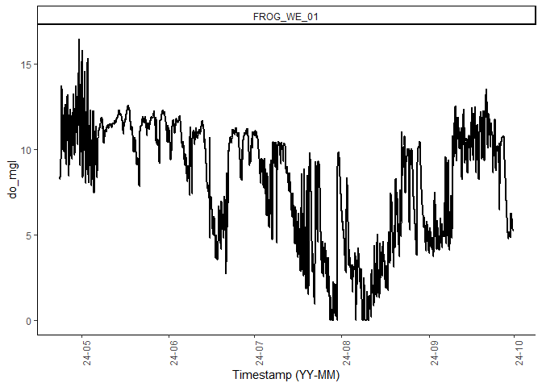

```r
do_plot
```

## Attach Barometric Data (v0.2)

We need atmospheric pressure at each timestamp to:

1. Convert DO from mg/L to percent saturation
2. Help detect dry-sensor conditions (comparing air and water temp)

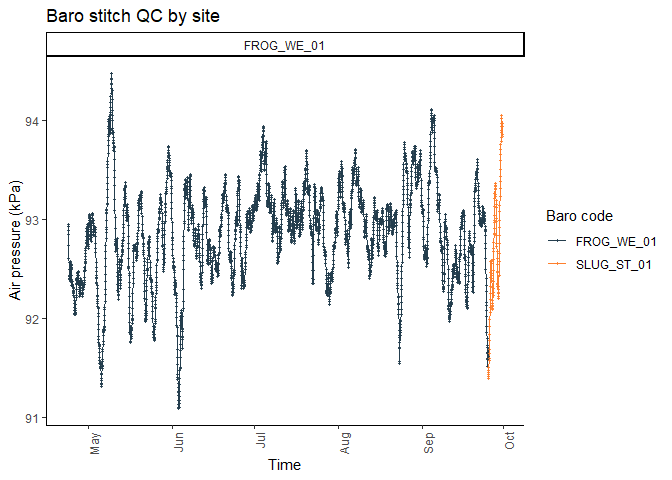

```r
do_with_baro <- add_nearest_baro(
  input_data          = do_data,
  baro_data_path      = baro_folder,
  metric              = "DO",
  metadata_path       = metadata_file
)

do_data <- do_with_baro[[1]]
do_with_baro[[2]]
```

```r
cat("After baro attach:", nrow(do_data), "rows\n")
```

```
#> After baro attach: 3847 rows
```

```r
cat("Baro station(s) used:",
    paste(unique(na.omit(do_data$baro_site_stn_code)), collapse = ", "), "\n")
```

```
#> Baro station(s) used: FROG_WE_01, SLUG_ST_01
```

```r
baro_na <- sum(is.na(do_data$airpress_kPa))
cat("Missing baro data:", baro_na, "of", nrow(do_data), "rows",
    paste0("(", round(baro_na / nrow(do_data) * 100, 1), "%)"), "\n")
```

```
#> Missing baro data: 0 of 3847 rows (0%)
```

## Convert DO mg/L to Percent Saturation (v0.3)

Calculates percent air saturation (%sat) from the DO concentration, water temperature, and atmospheric pressure.

Percent saturation tells you how much oxygen is in the water relative to what the water could hold at that temperature and pressure. It’s a better indicator of ecosystem health than mg/L alone because it accounts for physical conditions. For example, cold water holds more oxygen than warm water. So 8 mg/L in cold water might be only 70% saturated, while 8 mg/L in warm water might be 95% saturated.

The math uses the Weiss (1970/1974) oxygen solubility equation to calculate the theoretical maximum DO, then divides the measured DO by that maximum and multiplies by 100.

```r
do_data <- convert_do_mgl_percsat(do_data)

cat("DO %sat range:", round(min(do_data$do_percsat, na.rm = TRUE), 1), "to",
    round(max(do_data$do_percsat, na.rm = TRUE), 1), "%\n")
```

```
#> DO %sat range: -0.4 to 119 %
```

```r
head(do_data[, c("timestamp", "do_mgl", "watertemp_C",
                  "airpress_kPa", "do_percsat")])
```

```
#> # A tibble: 6 × 5
#>   timestamp           do_mgl watertemp_C airpress_kPa do_percsat
#>   <dttm>               <dbl>       <dbl>        <dbl>      <dbl>
#> 1 2024-04-23 10:00:00   8.4         21.2         92.9       103.
#> 2 2024-04-23 11:00:00   8.24        22.9         92.9       105.
#> 3 2024-04-23 12:00:00   8.38        22.8         92.9       106.
#> 4 2024-04-23 13:00:00   8.46        23.4         92.9       109.
#> 5 2024-04-23 14:00:00   8.41        24.1         92.8       110.
#> 6 2024-04-23 15:00:00   8.78        22.6         92.7       111.
```

## Automatic DO QC

Runs automatic quality checks on the dissolved oxygen data and creates adjusted columns with problematic values corrected or removed.

Adjusted columns created: `do_mgl_adj`, `do_percsat_adj`, `watertemp_C_do_adj`.

The same flag vs edit pattern applies: `FLAG_*` = “please review” (data unchanged), `OUTLIER_*` / `ERROR_*` = “we changed the data”.

You can specify where you would like the QC log (records all auto and manual QC changes to data) by specifying the file path in `log_root`.

```r
do_qc <- qc_dissox(
  input_data     = do_data,
  select_station = unique(do_data$site_station_code)[1]
)

cat("QC results:\n")
```

```
#> QC results:
```

```r
cat("  Total rows:       ", nrow(do_qc), "\n")
```

```
#>   Total rows:        3847
```

```r
cat("  Logger errors:    ", sum(do_qc$ERROR_DO, na.rm = TRUE), "\n")
```

```
#>   Logger errors:     0
```

```r
cat("  DO outliers:      ", sum(do_qc$OUTLIER_DO, na.rm = TRUE), "\n")
```

```
#>   DO outliers:       23
```

```r
cat("  Temp outliers:    ", sum(do_qc$OUTLIER_WT, na.rm = TRUE), "\n")
```

```
#>   Temp outliers:     9
```

```r
cat("  Ice flagged:      ", sum(do_qc$FLAG_ICE, na.rm = TRUE), "\n")
```

```
#>   Ice flagged:       18
```

```r
cat("  Dry flagged:      ", sum(do_qc$FLAG_DRY, na.rm = TRUE), "\n")
```

```
#>   Dry flagged:       0
```

```r
cat("  Range flagged:    ", sum(do_qc$FLAG_RANGE, na.rm = TRUE), "\n")
```

```
#>   Range flagged:     28
```

```r
qaqc_log <- attr(do_qc, "qaqc_log")
if (!is.null(qaqc_log) && nrow(qaqc_log) > 0) {
  cat("QC log entries:\n")
  print(qaqc_log[, c("field", "action", "code", "ts_start", "ts_end")])
}
```

```
#> QC log entries:
#> # A tibble: 26 × 5
#>    field              action  code       ts_start            ts_end
#>    <chr>              <chr>   <chr>      <dttm>              <dttm>
#>  1 do_mgl_adj         AUTO_QC OUTLIER_DO 2024-07-28 15:00:00 2024-07-29 01:00:00
#>  2 do_mgl_adj         AUTO_QC OUTLIER_DO 2024-07-30 09:00:00 2024-07-30 09:00:00
#>  3 do_mgl_adj         AUTO_QC OUTLIER_DO 2024-08-06 02:00:00 2024-08-06 03:00:00
#>  4 do_mgl_adj         AUTO_QC OUTLIER_DO 2024-08-09 06:00:00 2024-08-09 13:00:00
#>  5 do_mgl_adj         AUTO_QC OUTLIER_DO 2024-08-10 10:00:00 2024-08-10 10:00:00
#>  6 watertemp_C_do_adj AUTO_QC OUTLIER_WT 2024-04-30 03:00:00 2024-04-30 06:00:00
#>  7 watertemp_C_do_adj AUTO_QC OUTLIER_WT 2024-05-01 05:00:00 2024-05-01 07:00:00
#>  8 watertemp_C_do_adj AUTO_QC OUTLIER_WT 2024-05-03 05:00:00 2024-05-03 06:00:00
#>  9 watertemp_C_do_adj AUTO_QC FLAG_ICE   2024-04-30 01:00:00 2024-04-30 07:00:00
#> 10 watertemp_C_do_adj AUTO_QC FLAG_ICE   2024-05-01 02:00:00 2024-05-01 07:00:00
#> # ℹ 16 more rows
```

## Visual Review

Lets look at the data to see what QC flags were made by qc_dissox. Plotly is used as an interactive plotting feature to allow the user to overlay water data from multiple loggers ie. compare water temperature from dissolved oxygen logger to air temperature from barometric logger at the same site) and zoom in on time periods of interest; this helps to identify data where a logger has gone dry, frozen or been disturbed.

```r
plot_qc_timeseries(
  do_data        = do_qc,
  select_station = unique(do_qc$site_station_code)[1],
  static = TRUE
)
```

[output not shown]

How to read the plot:

- Light traces = raw values (original, unmodified)
- Dark traces = adjusted values (after auto QC)
- Colored dots = flag locations (ice, dry, error)
- Use the range slider at the bottom to zoom into specific periods
- Hover over points for exact values

You can zoom in on sections of the plot by clicking and dragging with your mouse. You can see data point values by hovering your mouse over the data point on the graph. You can also toggle data sources on and off by clicking on the data type in the legend.

## Manual Adjustments

This section demonstrates how to manually remove bad data. In a real project, you would apply these only after reviewing the plot and identifying specific problem periods.

For DO data, the three reasons for removal are:

- **“ice”** — sensor frozen in ice; DO readings are unreliable. Sets `do_mgl_adj`, `do_percsat_adj`, `watertemp_C_adj` to `NA`.
- **“dry”** — sensor exposed to air (water level dropped below it). Same columns set to `NA`.
- **“disturbance”** — physical disturbance (e.g., debris, maintenance). Sets DO columns to `NA` but can keep temperature with `keep_temp = TRUE`.

Each function returns a new data frame. Always assign the result back to your working variable so corrections accumulate.

Look for sections in the graph where:

- water temperature variation overlaps completely with air temperature variation. This suggests that the DO logger is dry.
- When air temperature is > 0C, and DO jumps up to >100% air sat. suddenly. This indicates the DO logger may be dry.
- When air temperature is < 0C, and DO jumps up to >100% air sat. suddenly. This indicates the DO logger is encased in ice and is reading air trapped in ice rather than water.

### A note on hypoxia and hyperoxia in wetlands

This is real data from a temperate wetland. Depending on your focal system, hypoxia may be rare (like in fast flowing rivers) or it could be quite common. In temperate wetlands during high summer temperatures, hypoxia is quite common and can cause DO to drop to 0 for extended periods of time. In addition, DO can spike from high oxygen production via algae and plant photosynthesis to over 100% DO. Note the OUTLIER_DO flags in August, which show an example of hypoxia. Based on field data, we know these values to be true and we will keep them in. When checking data flags, always consult field notes or field measurements to help in identifying whether data is truly erroneous.

### Remove an ice period

From the beginning of the dataset to ~“2024-05-06 21:00:00” DO shows large swings each day. This coincides with the dissolved oxygen logger water temp overlapping competely with air temperature. This is clearly a time when the DO logger was frozen in ice. We should remove this section of DO data.

The function adjust_logger_NA takes the inputs of your station data (input_data), the timestamp for the start of the dry period (timestamp_start) and the timestamp for the end of the dry period (timestamp_end). The timestamps must be formatted correctly in the same timezone as your dataset (Note: by default we force the UTC timezone so that R doesnt automatically correct for daylight saving since our loggers don’t correct for daylight savings - they just stay in Pacific Standard Time all year round). You need to tell the function why you are removing the data (ie. reason_to_adjust = “ice” )

```r
do_qc <- adjust_logger_NA(
  input_data       = do_qc,
  select_station   = "FROG_WE_01",
  metric           = "dissolvedoxygen",
  reason_to_adjust = "ice",
  timestamp_start  = "2024-04-10 13:00:00",
  timestamp_end    = "2024-05-06 21:00:00",
  manual_note      = "Ice confirmed from water and air temperature data",
  log_root = log_root_folder
)
```

Re-run plot_qc_timeseries to view the changes made. do_adj and watertemp_adj values should be removed for the selected time period.

```r
plot_qc_timeseries(
  do_data        = do_qc,
  select_station = unique(do_qc$site_station_code)[1],
  static = TRUE
)
```

[output not shown]

### Remove a dry period

```r
do_qc <- adjust_logger_NA(
  input_data       = do_qc,
  select_station   = "FROG_WE_01",
  metric           = "dissolvedoxygen",
  reason_to_adjust = "dry",
  timestamp_start  = "2024-09-09 06:00:00",
  timestamp_end    = "2024-09-25 21:00:00",
  manual_note      = "inferred from air and water temperature",
  log_root = log_root_folder
)
```

Again, re-run plot_qc_timeseries to see your changes.

```r
plot_qc_timeseries(
  do_data        = do_qc,
  select_station = unique(do_qc$site_station_code)[1],
  static = TRUE
)
```

[output not shown]

## Export Clean Data (v1.0)

Writes the final cleaned data to CSV files, one per station per year.

What gets exported:

- `site_station_code`, `timestamp` (identifiers)
- `do_mgl`, `do_mgl_adj` (raw and adjusted DO in mg/L)
- `do_percsat`, `do_percsat_adj` (raw and adjusted DO in %sat)
- `watertemp_C`, `watertemp_C_do_adj` (raw and adjusted water temperature)
- a `qc_code` column showing if data is “REAL”, “CORRECTED”, “REMOVED” or NA

```r
cat("Final dataset:", nrow(do_qc), "rows x", ncol(do_qc), "columns\n\n")
```

```
#> Final dataset: 3847 rows x 23 columns
```

```r
cat("Summary of unadjusted DO (mgl):\n")
```

```
#> Summary of unadjusted DO (mgl):
```

```r
print(summary(do_qc$do_mgl))
```

```
#>    Min. 1st Qu.  Median    Mean 3rd Qu.    Max.
#>  -0.030   5.360   9.420   8.249  11.020  16.460
```

```r
cat("\nSummary of adjusted DO (mgl):\n")
```

```
#>
#> Summary of adjusted DO (mgl):
```

```r
print(summary(do_qc$do_mgl_adj))
```

```
#>    Min. 1st Qu.  Median    Mean 3rd Qu.    Max.
#>   0.000   5.360   9.420   8.249  11.020  16.460
```

When you’re happy with your data cleaning, you can export the clean data. You must specify where you’d like the clean file to be saved under `path_to_output_folder`

```r
write_clean_data(
  input_data            = do_qc,
  path_to_output_folder = output,
  metric                = "dissolvedoxygen"
)
```

## Recap

| Step | Function | Result |
| --- | --- | --- |
| 1 | `bind_logger_files()` on DO | `do_data` (raw DO) |
| 2 | `add_nearest_baro()` | `do_data` (DO + baro attached) |
| 3 | `convert_do_mgl_percsat()` | `do_data` (adds %sat) |
| 4 | `qc_dissox()` | `do_qc` (auto QC’d) |
| 5 | `plot_qc_timeseries()` | (visual review) |
| 6 | Manual adjustments | `do_qc` (updated) |
| 7 | `plot_qc_timeseries()` | (final review) |
| 8 | `write_clean_data()` | CSV files on disk |

**Key columns:**

- `do_mgl` — raw DO in mg/L (never modified)
- `do_mgl_adj` — adjusted DO in mg/L (all corrections applied)
- `do_percsat` — raw DO in percent saturation (never modified)
- `do_percsat_adj` — adjusted DO in %sat (all corrections applied)
- `watertemp_C` — raw water temperature (never modified)
- `watertemp_C_do_adj` — adjusted water temperature
- `FLAG_*` — “something looks off — review” (data not changed)
- `OUTLIER_*` / `ERROR_*` — “data was changed” (set to NA or corrected)